# Analysis of Prices

Here we´ll analysis the prices each competitor gives over time in a data set and discover what it have to give us.

The data is described as bellow:

- PROD_ID: Product ID. the values varies between P1 to P9;
- DATE_EXTRACTION: Date and Time of the extraction of the competitors’ price, under YYYY-MM-DD HH:MM:SS format;
- COMPETITOR: Competitors’ ID (C1 to C6);
- COMPETITOR_PRICE: Competitors’ price per product, which can depend on the payment method;
- PAY_TYPE: Payment Method (1=deferred payment, 2=immediate payment)

```r
#loading the csv file
prices <-  read.csv("comp_prices.csv", sep=",", stringsAsFactors = T)

tail(prices)
```

```
##       PROD_ID     DATE_EXTRACTION COMPETITOR COMPETITOR_PRICE PAY_TYPE
## 50109      P5 2015-10-11 20:10:34         C3           819.00        2
## 50110      P5 2015-10-11 20:10:34         C1           819.00        2
## 50111      P5 2015-10-11 20:10:34         C2           853.52        2
## 50112      P5 2015-10-12 08:11:27         C2           853.52        1
## 50113      P5 2015-10-12 08:11:27         C3           819.00        1
## 50114      P5 2015-10-12 08:11:27         C1           819.00        1
```

As the data documentation tells us the competitor is monitored twice a day.

```r
prices <- arrange(prices, COMPETITOR, PROD_ID, DATE_EXTRACTION)

tail(prices)
```

```
##       PROD_ID     DATE_EXTRACTION COMPETITOR COMPETITOR_PRICE PAY_TYPE
## 50109      P9 2015-10-14 08:11:39         C6         39999.00        1
## 50110      P9 2015-10-14 08:11:39         C6         39999.00        2
## 50111      P9 2015-10-14 20:10:24         C6           399.99        1
## 50112      P9 2015-10-14 20:10:24         C6           399.99        2
## 50113      P9 2015-10-14 20:11:30         C6           399.99        1
## 50114      P9 2015-10-14 20:11:30         C6           399.99        2
```

Ordering the set by COMPETITOR, PROD_ID and DATE_EXTRACTION we can see that it´s true, we can turn that into a single line displaying it as min and max price.

```r
prices_min_max <- mutate(prices, YEAR = year(DATE_EXTRACTION),
                            MONTH = month(DATE_EXTRACTION),
                            DAY = day(DATE_EXTRACTION),
                            PROD_ID = as.factor(PROD_ID)) %>%
                  group_by(COMPETITOR, PROD_ID, YEAR, MONTH, DAY) %>%
                  summarise(MIN_PRICE = min(COMPETITOR_PRICE),
                            MAX_PRICE = max(COMPETITOR_PRICE)) %>%
                  arrange(COMPETITOR, PROD_ID, YEAR, MONTH, DAY)

tail(prices_min_max)
```

```
## Source: local data frame [6 x 7]
## Groups: COMPETITOR, PROD_ID, YEAR, MONTH [1]
##
##   COMPETITOR PROD_ID  YEAR MONTH   DAY MIN_PRICE MAX_PRICE
##       <fctr>  <fctr> <dbl> <dbl> <int>     <dbl>     <dbl>
## 1         C6      P9  2015    10     9    399.99    399.99
## 2         C6      P9  2015    10    10    399.99    399.99
## 3         C6      P9  2015    10    11    399.99    399.99
## 4         C6      P9  2015    10    12    399.99    399.99
## 5         C6      P9  2015    10    13    399.99    399.99
## 6         C6      P9  2015    10    14    399.99  39999.00
```

## Distribuition of products by competitor

With the data in our hands we can try to discrinate the presence of competitors in the market showing the products it sells.

```r
presence_market <- group_by(prices_min_max, COMPETITOR, PROD_ID) %>%
                   summarise(M = n())

tail(presence_market)
```

```
## Source: local data frame [6 x 3]
## Groups: COMPETITOR [1]
##
##   COMPETITOR PROD_ID     M
##       <fctr>  <fctr> <int>
## 1         C6      P3   207
## 2         C6      P4   153
## 3         C6      P6   278
## 4         C6      P7   235
## 5         C6      P8   156
## 6         C6      P9   154
```

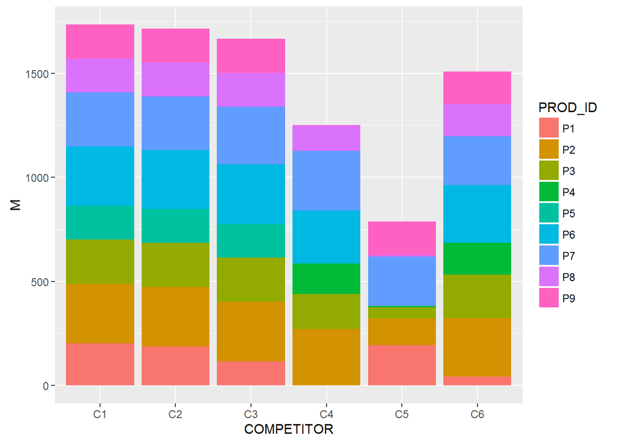

```r
g <- ggplot(presence_market, aes(y = M, x = COMPETITOR))

g +  geom_bar(stat = "identity", aes(fill = PROD_ID))
```

## The competitor with lowest price by product

With our data we can see the now what are the competitor with the best price by product.

```r
competitor_best_price <- group_by(prices_min_max, PROD_ID, COMPETITOR) %>%
                         summarise(PRICE = min(MIN_PRICE)) %>%
                         slice(which.min(PRICE))

competitor_best_price
```

```
## Source: local data frame [9 x 3]
## Groups: PROD_ID [9]
##
##   PROD_ID COMPETITOR   PRICE
##    <fctr>     <fctr>   <dbl>
## 1      P1         C1 1090.00
## 2      P2         C4  506.92
## 3      P3         C1  879.12
## 4      P4         C4  431.10
## 5      P5         C1  674.10
## 6      P6         C1 1225.97
## 7      P7         C1  588.71
## 8      P8         C1  359.10
## 9      P9         C1  359.10
```

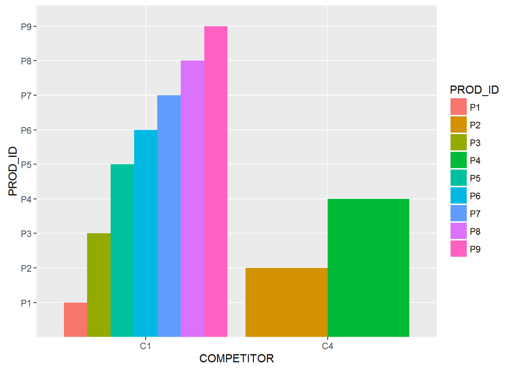

```r
g <- ggplot(competitor_best_price, aes(y = PROD_ID, x = COMPETITOR))

g +  geom_bar(stat = "identity", aes(fill = PROD_ID), position = "dodge")
```

The competitor C1 has the best prices for almost all products, loosing to C4 in just two products P2 and P4.

## The competitor with the highest prices

Now let´s see the competitor with the highest prices.

```r
competitor_worst_price <- group_by(prices_min_max, PROD_ID, COMPETITOR) %>%
                         summarise(PRICE = max(MAX_PRICE)) %>%
                         slice(which.max(PRICE))

competitor_worst_price
```

```
## Source: local data frame [9 x 3]
## Groups: PROD_ID [9]
##
##   PROD_ID COMPETITOR  PRICE
##    <fctr>     <fctr>  <dbl>
## 1      P1         C1 149900
## 2      P2         C4  79900
## 3      P3         C1 119900
## 4      P4         C6  49700
## 5      P5         C2  84890
## 6      P6         C6 149900
## 7      P7         C3 104900
## 8      P8         C6  39999
## 9      P9         C5  56900
```

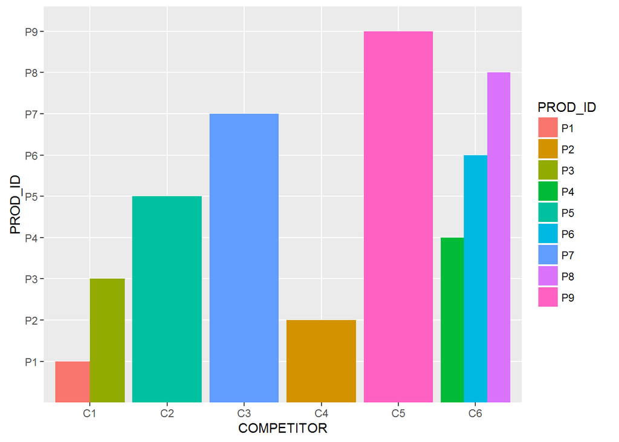

```r
g <- ggplot(competitor_worst_price, aes(y = PROD_ID, x = COMPETITOR))

g +  geom_bar(stat = "identity", aes(fill = PROD_ID), position = "dodge")
```

Diferently from the lowest prices, we can see a better distribuition over the competitors.

## The lowest and higher prices per competitor by product

It´s intereting to compare the prices each competitor has, historically, for each product in terms to understand more about their behaviors during the year.

```r
comp_best_worst_pric_prod <- group_by(prices_min_max, COMPETITOR, PROD_ID) %>%
                             summarise(MIN_PRICE = min(MIN_PRICE),
                                       MAX_PRICE = max(MAX_PRICE)) %>%
                             arrange(COMPETITOR, PROD_ID)

comp_best_worst_pric_prod
```

```
## Source: local data frame [46 x 4]
## Groups: COMPETITOR [6]
##
##    COMPETITOR PROD_ID MIN_PRICE MAX_PRICE
##        <fctr>  <fctr>     <dbl>     <dbl>
## 1          C1      P1   1090.00    149900
## 2          C1      P2    539.10     72498
## 3          C1      P3    879.12    119900
## 4          C1      P5    674.10     81900
## 5          C1      P6   1225.97    148000
## 6          C1      P7    588.71     84090
## 7          C1      P8    359.10     39300
## 8          C1      P9    359.10     39300
## 9          C2      P1   1099.00    149900
## 10         C2      P2    539.10     72498
## # ... with 36 more rows
```

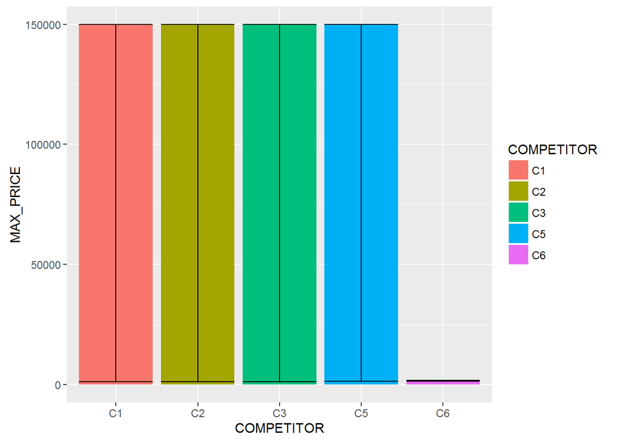

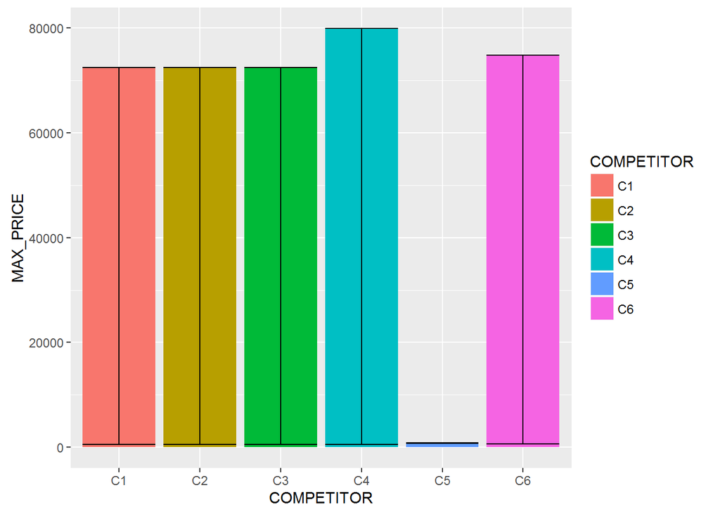

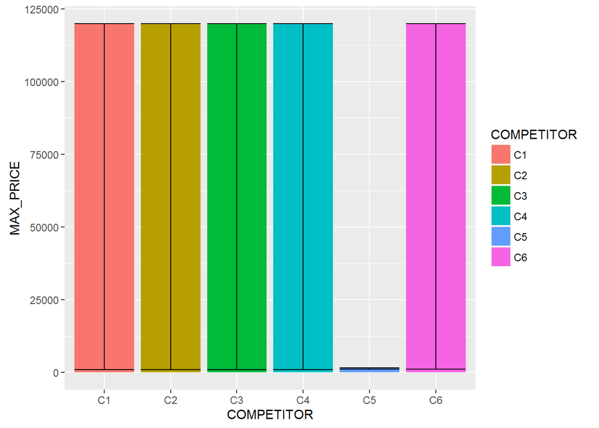

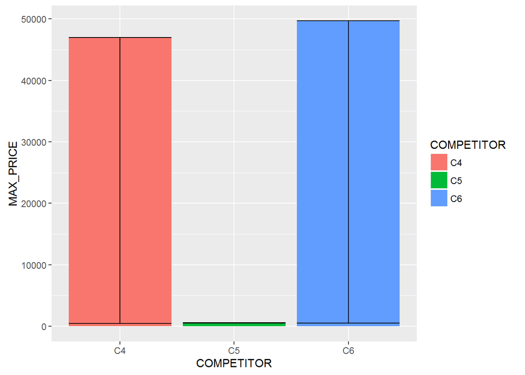

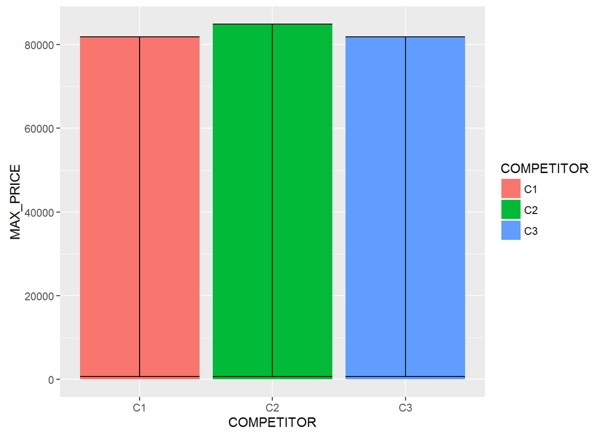

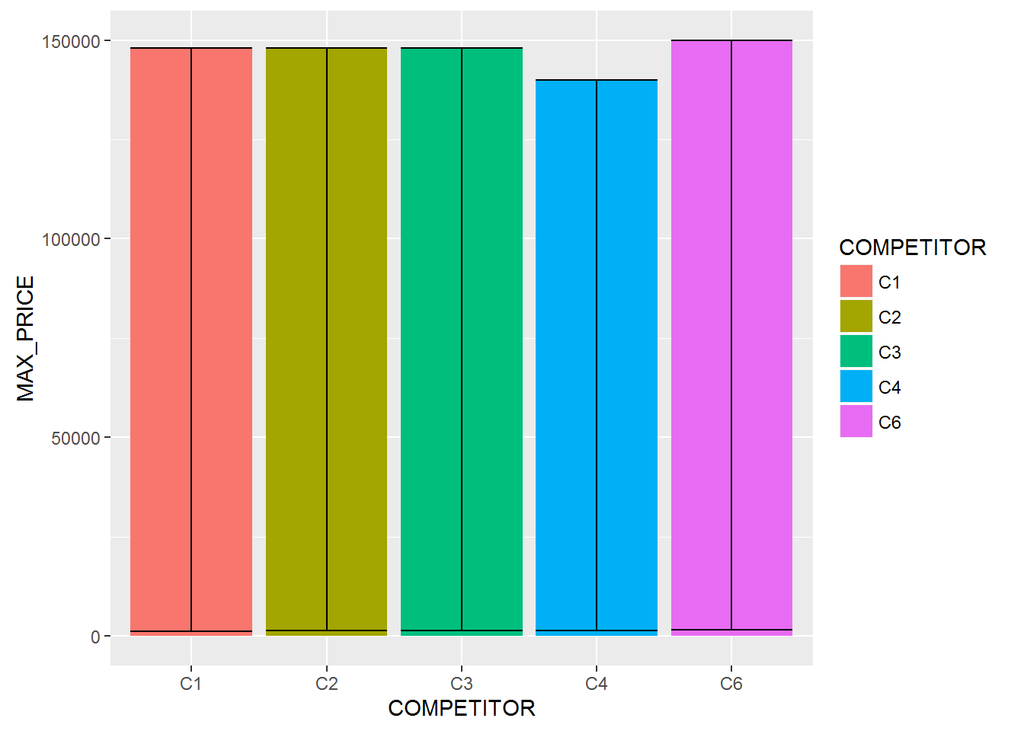

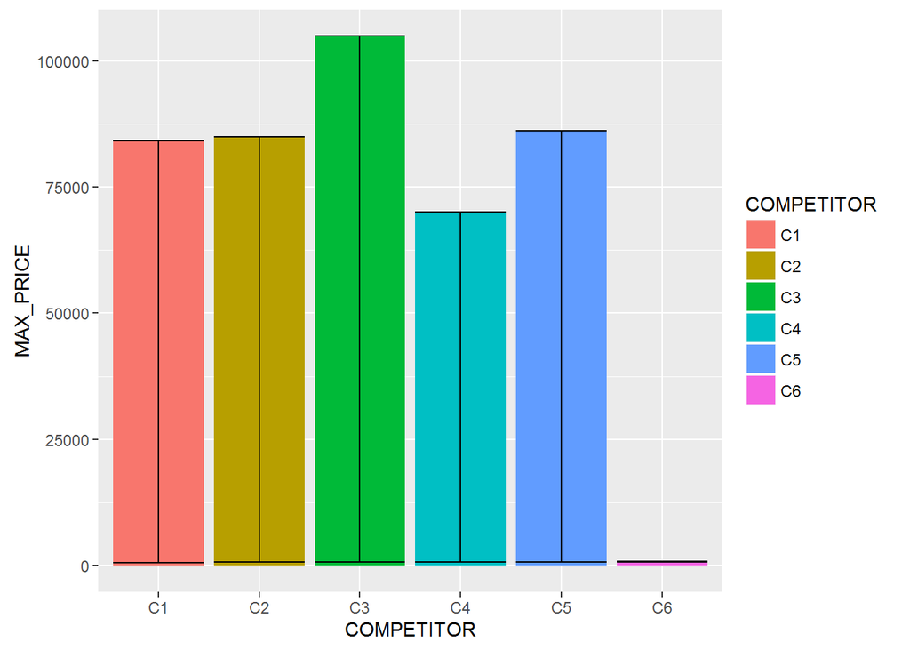

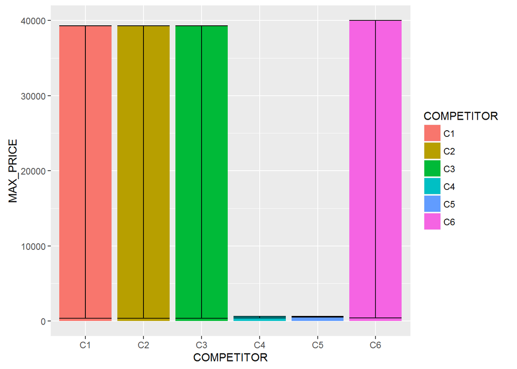

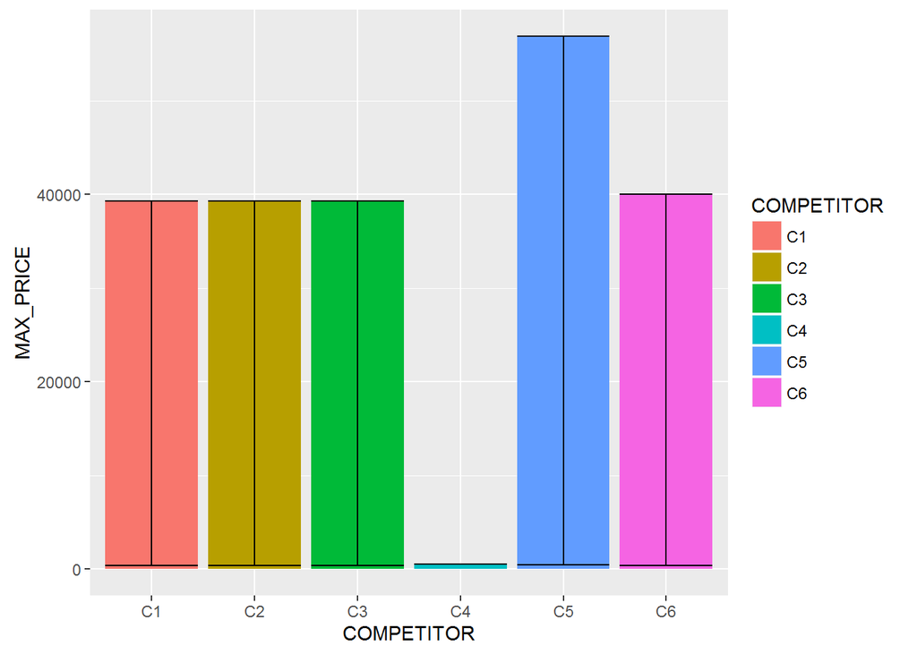

```r
plots <- c()
i <- 1
for(product in levels(comp_best_worst_pric_prod$PROD_ID)){

  g <- ggplot(filter(comp_best_worst_pric_prod, PROD_ID == product), aes(y = MAX_PRICE, x = COMPETITOR, ymin = MIN_PRICE, ymax = MAX_PRICE, fill = COMPETITOR))

  g <- g +  geom_bar(stat = "identity") +
  geom_errorbar()


  print(g)
}
```